# FoRt: Tests & Testabdeckung: testthat & covr

## Übliches Vorgehen

Entwicklung eines einzelnen Skripts:

- herumprobieren in der Kommandozeile
- modifiziere bis Rechner gehorcht, dann kopiere Befehle in ein File

ODER

- Arbeit mit mehreren Files
- `source()` auf alles & Output begutachten
- modifizieren & wiederholen

Beides ist chaotisch & fehlerträchtig wenn man saubere, reproduzierbare Analysen oder eben Pakete entwickeln möchte.

## Entwicklungsstile

- konfirmatorisches Programmieren: nur das “wie” ist unklar
  - Programmiererin weiß genau was sie tun muss & welches Ergebnis die vorzunehmenden Änderungen haben sollen
  - *test-driven development*
- exploratives Programmieren:
  - lose Idee was am Ende rauskommen soll
  - nicht sicher über Dinge wie die richtige Kapselung der Sub-Funktionen, Details der inputs/outputs, etc.
- möglichst konfirmatorisch arbeiten wenn man etwas neues von Grund auf entwickelt (*top-down programming*!)
- Debugging und Feature-Erweiterung zu Beginn oft eher explorativ

## Exploratives Programmieren

Workflow:

1. ändere Code und lade neu mit `load_all()`
2. begutachte Effekt der Änderungen
3. wiederhole 1. und 2. bis Ziel erreicht
4. aktualisiere Doku, generiere Hilfe mit `document()`
5. `check("pkg")`
6. `build("pkg")`

## Konfirmatorisches Programmieren

Workflow:

1. schreibe versagende Tests für Bug oder für fehlendes Feature
2. ändere Code und lade neu mit `load_all()`
3. lasse alle Tests die sich für das Paket angesammelt haben laufen (mit `test()` falls `testthat` benutzt wird, sonst per `source()` der Testscripts.)
4. wiederhole 2. und 3. bis kein Test mehr versagt
5. aktualisiere Doku, generiere Hilfe mit `document()`
6. `check("pkg")`
7. `build("pkg")`

## Konfirmatorisches Programmieren

- weniger Frust, weniger Bugs
- bessere Codestruktur:
  - leicht zu testen \(\iff\) gut designed (Kapselung!)
  - defensives Programmieren: Tests schreiben heisst Fehlerquellen antizipieren & aussschließen
- leichter Wiedereinstieg nach Pause
  - versagende Tests als to-do Liste
- mehr Selbstvertrauen um große Änderungen zu wagen:
  - Verschlimmbesserungen sofort sichtbar falls die Testabdeckung gut genug ist (*regression tests*)

## `testthat`

## `testthat` & `checkmate`

hierarchische Struktur:

- `expectation` beschreibt das erwartete Ergebnis eines Befehls
  - Wert, Klasse, korrekte Fehlermeldung, Rechenzeit, …?
  - definiert mit `expect_that`
- `test` gruppiert mehrere `expectation`s für eine Funktion oder ein Feature
  - definiert mit `test_that()`
- `context()` gruppiert mehrere thematisch verwandte Tests
- `checkmate` definiert weitere hilfreiche `expect_XXX()`-Funktionen.

## Tests testen

- Ordnerstruktur etc. mit `usethis::use_testthat()` anlegen
- `testthat::test_package(<pkgname>)`, `testthat::test_check()`
- `devtools::test()`
- `R CMD check`, `devtools::check()`

## R CMD check

- alle Testfiles in Unterordner `tests/testthat`
- Namen von Test-Files fangen mit “test-” an.
- Datei `tests/test-all.R` mit

```r
library(testthat)
test_check("pkgname")
```

- `DESCRIPTION` muss `Suggests: testthat` enthalten
- `R CMD check` versagt wenn nicht alle Tests erfolgreich verlaufen

## Testabdeckung prüfen mit `covr`:

[`covr`](https://github.com/jimhester/covr) startet `shiny`-App die visualisiert welche Funktionen/Files wo & wie gut durch Tests abgedeckt sind:

```r
cov <- covr::package_coverage()
shine(cov)
```

## `covr`: Testabdeckung `refund`-Paket

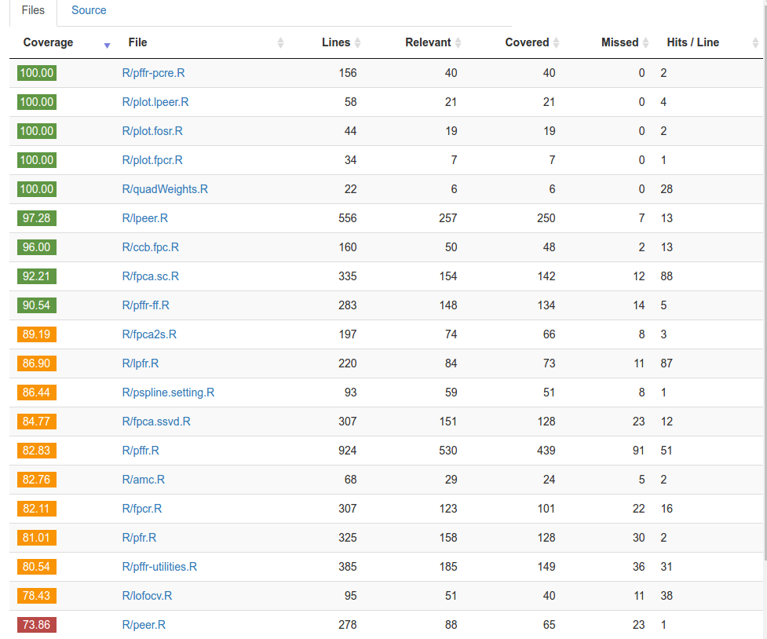

## `covr`: Testabdeckung `refund::fosr()`

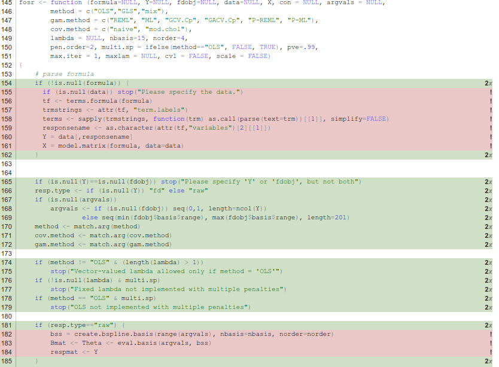

## Tests schreiben

Desiderata für Tests:

- **testen nur Verhalten, nie Struktur**: Tests sollten Ergebnis nur ändern wenn sich das Ergebnis der Berechnung ändert, *nicht* wenn die dahinter liegende Implementation sich ändert.
- **spezifisch**: testen *einen* (1!) ganz bestimmten Aspekt des Programms
- **schnell**: Testfiles laufen immer und immer wieder, also dürfen Sie nicht zu lange brauchen
- **einfach**: viel einfacher zu *schreiben* als der zu testende Code, einfacher zu *lesen* und zu verstehen als der getestete Code

Außerdem:

- **isoliert**: Tests liefern identische Ergebnisse unabhängig von Reihenfolge in der sie geprüft werden, damit werden sie auch einfach **kombinierbar**
- **automatisiert**
- **deterministisch**